# Risk Factor Analysis

## Outcome Variable

**Outcome Variable:** ever_stunted

## Predictor Variables

**Intervention Variable:** gagebrth

**Adjustment Set:**

unadjusted

## Stratifying Variables

The analysis was stratified on these variable(s):

- agecat
- studyid

The following strata were considered:

- agecat: 12 months, studyid: ki1000108-CMC-V-BCS-2002
- agecat: 12 months, studyid: ki1000108-IRC
- agecat: 12 months, studyid: ki1000109-EE
- agecat: 12 months, studyid: ki1066203-TanzaniaChild2
- agecat: 12 months, studyid: ki1101329-Keneba
- agecat: 12 months, studyid: ki1113344-GMS-Nepal
- agecat: 12 months, studyid: ki1135781-COHORTS
- agecat: 18 months, studyid: ki1000108-CMC-V-BCS-2002
- agecat: 18 months, studyid: ki1000108-IRC
- agecat: 18 months, studyid: ki1000109-EE
- agecat: 18 months, studyid: ki1066203-TanzaniaChild2
- agecat: 18 months, studyid: ki1101329-Keneba
- agecat: 18 months, studyid: ki1113344-GMS-Nepal
- agecat: 18 months, studyid: ki1135781-COHORTS
- agecat: 24 months, studyid: ki1000108-CMC-V-BCS-2002
- agecat: 24 months, studyid: ki1000108-IRC
- agecat: 24 months, studyid: ki1000109-EE
- agecat: 24 months, studyid: ki1066203-TanzaniaChild2
- agecat: 24 months, studyid: ki1101329-Keneba
- agecat: 24 months, studyid: ki1113344-GMS-Nepal
- agecat: 24 months, studyid: ki1135781-COHORTS
- agecat: 3 months, studyid: ki1000108-CMC-V-BCS-2002
- agecat: 3 months, studyid: ki1000108-IRC
- agecat: 3 months, studyid: ki1000109-EE
- agecat: 3 months, studyid: ki1066203-TanzaniaChild2
- agecat: 3 months, studyid: ki1101329-Keneba
- agecat: 3 months, studyid: ki1113344-GMS-Nepal
- agecat: 3 months, studyid: ki1135781-COHORTS
- agecat: 6 months, studyid: ki1000108-CMC-V-BCS-2002
- agecat: 6 months, studyid: ki1000108-IRC
- agecat: 6 months, studyid: ki1000109-EE
- agecat: 6 months, studyid: ki1066203-TanzaniaChild2
- agecat: 6 months, studyid: ki1101329-Keneba
- agecat: 6 months, studyid: ki1113344-GMS-Nepal
- agecat: 6 months, studyid: ki1135781-COHORTS

### Dropped Strata

Some strata were dropped due to rare outcomes:

- agecat: 3 months, studyid: ki1000109-EE
- agecat: 3 months, studyid: ki1113344-GMS-Nepal
- agecat: 6 months, studyid: ki1000109-EE
- agecat: 6 months, studyid: ki1113344-GMS-Nepal
- agecat: 12 months, studyid: ki1000109-EE
- agecat: 12 months, studyid: ki1113344-GMS-Nepal
- agecat: 18 months, studyid: ki1000109-EE
- agecat: 18 months, studyid: ki1113344-GMS-Nepal
- agecat: 24 months, studyid: ki1000108-CMC-V-BCS-2002
- agecat: 24 months, studyid: ki1000109-EE
- agecat: 24 months, studyid: ki1113344-GMS-Nepal

## Methods Detail

We’re interested in the causal parameters $E[Y_a]$ for all values of $a \in \mathcal{A}$. These parameters represent the mean outcome if, possibly contrary to fact, we intervened to set all units to have $A=a$. Under the randomization and positivity assumptions, these are identified by the statistical parameters $\psi_a=E_W[E_{Y|A,W}(Y|A=a,W)]$. In addition, we’re interested in the mean of $Y$, $E[Y]$ under no intervention (the observed mean). We will estimate these parameters by using SuperLearner to fit the relevant likelihood factors – $E_{Y|A,W}(Y|A=a,W)$ and $p(A=a|W)$, and then updating our likelihood fit using a joint TMLE.

For unadjusted analyses ($W=\{\}$), initial likelihoods were estimated using Lrnr_glm to estimate the simple $E(Y|A)$ and Lrnr_mean to estimate $p(A)$. For adjusted analyses, a small library containing Lrnr_glmnet, Lrnr_xgboost, and Lrnr_mean was used.

Having estimated these parameters, we will then use the delta method to estimate relative risks and attributable risks relative to a prespecified baseline level of $A$.

# Results Detail

## Results Plots

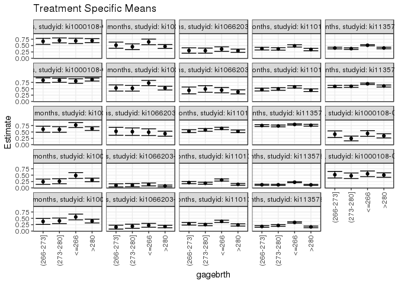

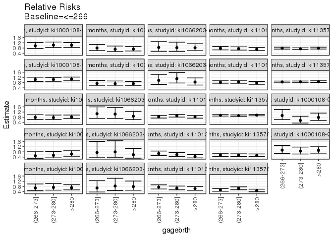

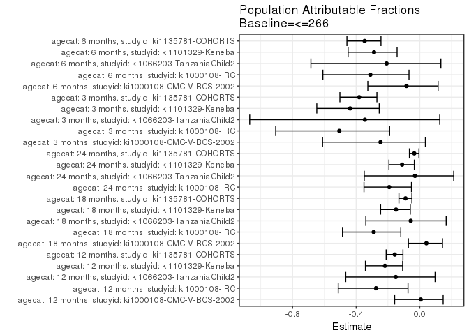

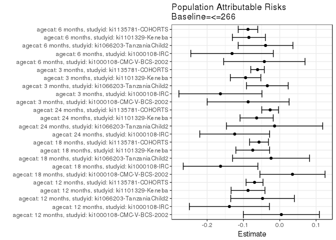

## Data Summary

| agecat | studyid | A | n | nA | nAY0 | nAY1 |
| --- | --- | --- | --- | --- | --- | --- |
| 3 months | ki1000108-CMC-V-BCS-2002 | <=266 | 340 | 75 | 42 | 33 |
| 3 months | ki1000108-CMC-V-BCS-2002 | (266-273] | 340 | 56 | 33 | 23 |
| 3 months | ki1000108-CMC-V-BCS-2002 | (273-280] | 340 | 82 | 62 | 20 |
| 3 months | ki1000108-CMC-V-BCS-2002 | >280 | 340 | 127 | 83 | 44 |
| 3 months | ki1000108-IRC | <=266 | 390 | 74 | 38 | 36 |
| 3 months | ki1000108-IRC | (266-273] | 390 | 66 | 50 | 16 |
| 3 months | ki1000108-IRC | (273-280] | 390 | 77 | 57 | 20 |
| 3 months | ki1000108-IRC | >280 | 390 | 173 | 119 | 54 |
| 3 months | ki1000109-EE | <=266 | 379 | 302 | 101 | 201 |
| 3 months | ki1000109-EE | (266-273] | 379 | 52 | 23 | 29 |
| 3 months | ki1000109-EE | (273-280] | 379 | 8 | 6 | 2 |
| 3 months | ki1000109-EE | >280 | 379 | 17 | 8 | 9 |
| 3 months | ki1066203-TanzaniaChild2 | <=266 | 565 | 135 | 117 | 18 |
| 3 months | ki1066203-TanzaniaChild2 | (266-273] | 565 | 90 | 81 | 9 |
| 3 months | ki1066203-TanzaniaChild2 | (273-280] | 565 | 94 | 84 | 10 |
| 3 months | ki1066203-TanzaniaChild2 | >280 | 565 | 246 | 227 | 19 |
| 3 months | ki1101329-Keneba | <=266 | 1558 | 469 | 324 | 145 |
| 3 months | ki1101329-Keneba | (266-273] | 1558 | 332 | 263 | 69 |
| 3 months | ki1101329-Keneba | (273-280] | 1558 | 373 | 305 | 68 |
| 3 months | ki1101329-Keneba | >280 | 1558 | 384 | 331 | 53 |
| 3 months | ki1113344-GMS-Nepal | <=266 | 593 | 1 | 0 | 1 |
| 3 months | ki1113344-GMS-Nepal | (266-273] | 593 | 588 | 495 | 93 |
| 3 months | ki1113344-GMS-Nepal | (273-280] | 593 | 0 | 0 | 0 |
| 3 months | ki1113344-GMS-Nepal | >280 | 593 | 4 | 4 | 0 |
| 3 months | ki1135781-COHORTS | <=266 | 4749 | 1920 | 1494 | 426 |
| 3 months | ki1135781-COHORTS | (266-273] | 4749 | 894 | 786 | 108 |
| 3 months | ki1135781-COHORTS | (273-280] | 4749 | 956 | 842 | 114 |
| 3 months | ki1135781-COHORTS | >280 | 4749 | 979 | 864 | 115 |
| 6 months | ki1000108-CMC-V-BCS-2002 | <=266 | 345 | 76 | 34 | 42 |
| 6 months | ki1000108-CMC-V-BCS-2002 | (266-273] | 345 | 58 | 28 | 30 |

[output cut: 110 more lines]

## Results Table

### Parameter: TSM

| agecat | studyid | intervention_level | baseline_level | estimate | ci_lower | ci_upper |
| --- | --- | --- | --- | --- | --- | --- |
| 3 months | ki1000108-CMC-V-BCS-2002 | <=266 | NA | 0.4400000 | 0.3274936 | 0.5525064 |
| 3 months | ki1000108-CMC-V-BCS-2002 | (266-273] | NA | 0.4107143 | 0.2816736 | 0.5397549 |
| 3 months | ki1000108-CMC-V-BCS-2002 | (273-280] | NA | 0.2439024 | 0.1508179 | 0.3369870 |
| 3 months | ki1000108-CMC-V-BCS-2002 | >280 | NA | 0.3464567 | 0.2635771 | 0.4293363 |
| 3 months | ki1000108-IRC | <=266 | NA | 0.4864865 | 0.3724612 | 0.6005117 |
| 3 months | ki1000108-IRC | (266-273] | NA | 0.2424242 | 0.1389018 | 0.3459467 |
| 3 months | ki1000108-IRC | (273-280] | NA | 0.2597403 | 0.1616735 | 0.3578070 |
| 3 months | ki1000108-IRC | >280 | NA | 0.3121387 | 0.2430023 | 0.3812751 |
| 3 months | ki1066203-TanzaniaChild2 | <=266 | NA | 0.1333333 | 0.0759400 | 0.1907266 |
| 3 months | ki1066203-TanzaniaChild2 | (266-273] | NA | 0.1000000 | 0.0379656 | 0.1620344 |
| 3 months | ki1066203-TanzaniaChild2 | (273-280] | NA | 0.1063830 | 0.0439979 | 0.1687680 |
| 3 months | ki1066203-TanzaniaChild2 | >280 | NA | 0.0772358 | 0.0438455 | 0.1106260 |
| 3 months | ki1101329-Keneba | <=266 | NA | 0.3091684 | 0.2673291 | 0.3510078 |
| 3 months | ki1101329-Keneba | (266-273] | NA | 0.2078313 | 0.1641714 | 0.2514912 |
| 3 months | ki1101329-Keneba | (273-280] | NA | 0.1823056 | 0.1431108 | 0.2215004 |
| 3 months | ki1101329-Keneba | >280 | NA | 0.1380208 | 0.1035110 | 0.1725306 |
| 3 months | ki1135781-COHORTS | <=266 | NA | 0.2218750 | 0.2032875 | 0.2404625 |
| 3 months | ki1135781-COHORTS | (266-273] | NA | 0.1208054 | 0.0994400 | 0.1421708 |
| 3 months | ki1135781-COHORTS | (273-280] | NA | 0.1192469 | 0.0987014 | 0.1397923 |
| 3 months | ki1135781-COHORTS | >280 | NA | 0.1174668 | 0.0972959 | 0.1376377 |
| 6 months | ki1000108-CMC-V-BCS-2002 | <=266 | NA | 0.5526316 | 0.4406821 | 0.6645811 |
| 6 months | ki1000108-CMC-V-BCS-2002 | (266-273] | NA | 0.5172414 | 0.3884532 | 0.6460296 |
| 6 months | ki1000108-CMC-V-BCS-2002 | (273-280] | NA | 0.4761905 | 0.3692318 | 0.5831491 |
| 6 months | ki1000108-CMC-V-BCS-2002 | >280 | NA | 0.5039370 | 0.4168541 | 0.5910200 |
| 6 months | ki1000108-IRC | <=266 | NA | 0.5540541 | 0.4406549 | 0.6674532 |
| 6 months | ki1000108-IRC | (266-273] | NA | 0.3787879 | 0.2616076 | 0.4959682 |
| 6 months | ki1000108-IRC | (273-280] | NA | 0.4025974 | 0.2929162 | 0.5122786 |
| 6 months | ki1000108-IRC | >280 | NA | 0.3918129 | 0.3185526 | 0.4650731 |
| 6 months | ki1066203-TanzaniaChild2 | <=266 | NA | 0.2268908 | 0.1515691 | 0.3022124 |
| 6 months | ki1066203-TanzaniaChild2 | (266-273] | NA | 0.1547619 | 0.0773431 | 0.2321807 |

[output cut: 66 more lines]

### Parameter: E(Y)

| agecat | studyid | intervention_level | baseline_level | estimate | ci_lower | ci_upper |
| --- | --- | --- | --- | --- | --- | --- |
| 3 months | ki1000108-CMC-V-BCS-2002 | NA | NA | 0.3529412 | 0.3453355 | 0.3605468 |
| 3 months | ki1000108-IRC | NA | NA | 0.3230769 | 0.3147552 | 0.3313986 |
| 3 months | ki1066203-TanzaniaChild2 | NA | NA | 0.0991150 | 0.0972750 | 0.1009551 |
| 3 months | ki1101329-Keneba | NA | NA | 0.2150193 | 0.2117256 | 0.2183129 |
| 3 months | ki1135781-COHORTS | NA | NA | 0.1606654 | 0.1592308 | 0.1621000 |
| 6 months | ki1000108-CMC-V-BCS-2002 | NA | NA | 0.5101449 | 0.5073470 | 0.5129428 |
| 6 months | ki1000108-IRC | NA | NA | 0.4226804 | 0.4162859 | 0.4290749 |
| 6 months | ki1066203-TanzaniaChild2 | NA | NA | 0.1877395 | 0.1857113 | 0.1897676 |
| 6 months | ki1101329-Keneba | NA | NA | 0.2959184 | 0.2929644 | 0.2988723 |
| 6 months | ki1135781-COHORTS | NA | NA | 0.2524373 | 0.2496335 | 0.2552411 |
| 12 months | ki1000108-CMC-V-BCS-2002 | NA | NA | 0.6885714 | 0.6873419 | 0.6898009 |
| 12 months | ki1000108-IRC | NA | NA | 0.5051546 | 0.4982130 | 0.5120963 |
| 12 months | ki1066203-TanzaniaChild2 | NA | NA | 0.3146552 | 0.3121438 | 0.3171666 |
| 12 months | ki1101329-Keneba | NA | NA | 0.3990796 | 0.3961957 | 0.4019635 |
| 12 months | ki1135781-COHORTS | NA | NA | 0.4417924 | 0.4401037 | 0.4434811 |
| 18 months | ki1000108-CMC-V-BCS-2002 | NA | NA | 0.8376068 | 0.8352516 | 0.8399621 |
| 18 months | ki1000108-IRC | NA | NA | 0.5629820 | 0.5551774 | 0.5707867 |
| 18 months | ki1066203-TanzaniaChild2 | NA | NA | 0.4230769 | 0.4185214 | 0.4276325 |
| 18 months | ki1101329-Keneba | NA | NA | 0.4989817 | 0.4963718 | 0.5015915 |
| 18 months | ki1135781-COHORTS | NA | NA | 0.6385460 | 0.6367926 | 0.6402994 |
| 24 months | ki1000108-IRC | NA | NA | 0.6461538 | 0.6400448 | 0.6522629 |
| 24 months | ki1066203-TanzaniaChild2 | NA | NA | 0.4765957 | 0.4716432 | 0.4815483 |
| 24 months | ki1101329-Keneba | NA | NA | 0.5733057 | 0.5709210 | 0.5756903 |
| 24 months | ki1135781-COHORTS | NA | NA | 0.7682073 | 0.7673325 | 0.7690821 |

### Parameter: RR

| agecat | studyid | intervention_level | baseline_level | estimate | ci_lower | ci_upper |
| --- | --- | --- | --- | --- | --- | --- |
| 3 months | ki1000108-CMC-V-BCS-2002 | (266-273] | <=266 | 0.9334416 | 0.6225312 | 1.3996296 |
| 3 months | ki1000108-CMC-V-BCS-2002 | (273-280] | <=266 | 0.5543237 | 0.3501506 | 0.8775503 |
| 3 months | ki1000108-CMC-V-BCS-2002 | >280 | <=266 | 0.7874016 | 0.5547876 | 1.1175471 |
| 3 months | ki1000108-IRC | (266-273] | <=266 | 0.4983165 | 0.3061606 | 0.8110753 |
| 3 months | ki1000108-IRC | (273-280] | <=266 | 0.5339105 | 0.3423503 | 0.8326572 |
| 3 months | ki1000108-IRC | >280 | <=266 | 0.6416185 | 0.4647551 | 0.8857875 |
| 3 months | ki1066203-TanzaniaChild2 | (266-273] | <=266 | 0.7500000 | 0.3524872 | 1.5958028 |
| 3 months | ki1066203-TanzaniaChild2 | (273-280] | <=266 | 0.7978723 | 0.3854858 | 1.6514233 |
| 3 months | ki1066203-TanzaniaChild2 | >280 | <=266 | 0.5792683 | 0.3147242 | 1.0661771 |
| 3 months | ki1101329-Keneba | (266-273] | <=266 | 0.6722268 | 0.5235886 | 0.8630611 |
| 3 months | ki1101329-Keneba | (273-280] | <=266 | 0.5896644 | 0.4573792 | 0.7602097 |
| 3 months | ki1101329-Keneba | >280 | <=266 | 0.4464260 | 0.3359514 | 0.5932291 |
| 3 months | ki1135781-COHORTS | (266-273] | <=266 | 0.5444749 | 0.4477011 | 0.6621671 |
| 3 months | ki1135781-COHORTS | (273-280] | <=266 | 0.5374506 | 0.4437477 | 0.6509402 |
| 3 months | ki1135781-COHORTS | >280 | <=266 | 0.5294278 | 0.4373506 | 0.6408905 |
| 6 months | ki1000108-CMC-V-BCS-2002 | (266-273] | <=266 | 0.9359606 | 0.6789760 | 1.2902109 |
| 6 months | ki1000108-CMC-V-BCS-2002 | (273-280] | <=266 | 0.8616780 | 0.6367723 | 1.1660196 |
| 6 months | ki1000108-CMC-V-BCS-2002 | >280 | <=266 | 0.9118860 | 0.6987182 | 1.1900880 |
| 6 months | ki1000108-IRC | (266-273] | <=266 | 0.6836659 | 0.4717910 | 0.9906911 |
| 6 months | ki1000108-IRC | (273-280] | <=266 | 0.7266392 | 0.5168124 | 1.0216562 |
| 6 months | ki1000108-IRC | >280 | <=266 | 0.7071744 | 0.5359587 | 0.9330863 |
| 6 months | ki1066203-TanzaniaChild2 | (266-273] | <=266 | 0.6820988 | 0.3742032 | 1.2433318 |
| 6 months | ki1066203-TanzaniaChild2 | (273-280] | <=266 | 0.8325103 | 0.4841392 | 1.4315581 |
| 6 months | ki1066203-TanzaniaChild2 | >280 | <=266 | 0.7890991 | 0.5119062 | 1.2163897 |
| 6 months | ki1101329-Keneba | (266-273] | <=266 | 0.7488245 | 0.6066148 | 0.9243726 |
| 6 months | ki1101329-Keneba | (273-280] | <=266 | 0.6713362 | 0.5413531 | 0.8325293 |
| 6 months | ki1101329-Keneba | >280 | <=266 | 0.6308702 | 0.5070589 | 0.7849131 |
| 6 months | ki1135781-COHORTS | (266-273] | <=266 | 0.5309501 | 0.4372741 | 0.6446939 |
| 6 months | ki1135781-COHORTS | (273-280] | <=266 | 0.6480332 | 0.5456146 | 0.7696771 |
| 6 months | ki1135781-COHORTS | >280 | <=266 | 0.4819347 | 0.3915669 | 0.5931580 |
| 12 months | ki1000108-CMC-V-BCS-2002 | (266-273] | <=266 | 0.9743590 | 0.7698507 | 1.2331941 |
| 12 months | ki1000108-CMC-V-BCS-2002 | (273-280] | <=266 | 1.0265568 | 0.8346514 | 1.2625856 |
| 12 months | ki1000108-CMC-V-BCS-2002 | >280 | <=266 | 1.0118343 | 0.8357226 | 1.2250580 |
| 12 months | ki1000108-IRC | (266-273] | <=266 | 0.8001289 | 0.5986997 | 1.0693279 |
| 12 months | ki1000108-IRC | (273-280] | <=266 | 0.7059961 | 0.5237078 | 0.9517340 |
| 12 months | ki1000108-IRC | >280 | <=266 | 0.7224146 | 0.5714715 | 0.9132266 |
| 12 months | ki1066203-TanzaniaChild2 | (266-273] | <=266 | 0.8439153 | 0.5521369 | 1.2898851 |
| 12 months | ki1066203-TanzaniaChild2 | (273-280] | <=266 | 0.8285714 | 0.5481092 | 1.2525436 |
| 12 months | ki1066203-TanzaniaChild2 | >280 | <=266 | 0.8172983 | 0.5909009 | 1.1304377 |
| 12 months | ki1101329-Keneba | (266-273] | <=266 | 0.7779487 | 0.6569810 | 0.9211899 |
| 12 months | ki1101329-Keneba | (273-280] | <=266 | 0.7570191 | 0.6425774 | 0.8918426 |
| 12 months | ki1101329-Keneba | >280 | <=266 | 0.7086257 | 0.5987862 | 0.8386139 |
| 12 months | ki1135781-COHORTS | (266-273] | <=266 | 0.7879408 | 0.7173230 | 0.8655107 |
| 12 months | ki1135781-COHORTS | (273-280] | <=266 | 0.7421348 | 0.6748954 | 0.8160733 |
| 12 months | ki1135781-COHORTS | >280 | <=266 | 0.7913374 | 0.7226890 | 0.8665067 |
| 18 months | ki1000108-CMC-V-BCS-2002 | (266-273] | <=266 | 1.0382514 | 0.8855545 | 1.2172778 |
| 18 months | ki1000108-CMC-V-BCS-2002 | (273-280] | <=266 | 1.0382514 | 0.8962302 | 1.2027779 |
| 18 months | ki1000108-CMC-V-BCS-2002 | >280 | <=266 | 1.0747090 | 0.9427964 | 1.2250784 |
| 18 months | ki1000108-IRC | (266-273] | <=266 | 0.7304174 | 0.5589422 | 0.9544986 |
| 18 months | ki1000108-IRC | (273-280] | <=266 | 0.7155109 | 0.5532177 | 0.9254149 |
| 18 months | ki1000108-IRC | >280 | <=266 | 0.7245065 | 0.5932214 | 0.8848462 |
| 18 months | ki1066203-TanzaniaChild2 | (266-273] | <=266 | 0.9707051 | 0.6582505 | 1.4314737 |
| 18 months | ki1066203-TanzaniaChild2 | (273-280] | <=266 | 1.0987996 | 0.7703989 | 1.5671890 |
| 18 months | ki1066203-TanzaniaChild2 | >280 | <=266 | 0.8446816 | 0.6152266 | 1.1597142 |
| 18 months | ki1101329-Keneba | (266-273] | <=266 | 0.8171572 | 0.7087176 | 0.9421890 |
| 18 months | ki1101329-Keneba | (273-280] | <=266 | 0.8573034 | 0.7504299 | 0.9793974 |
| 18 months | ki1101329-Keneba | >280 | <=266 | 0.7735096 | 0.6718681 | 0.8905278 |
| 18 months | ki1135781-COHORTS | (266-273] | <=266 | 0.8496307 | 0.7846260 | 0.9200209 |
| 18 months | ki1135781-COHORTS | (273-280] | <=266 | 0.8557807 | 0.7934174 | 0.9230458 |
| 18 months | ki1135781-COHORTS | >280 | <=266 | 0.8740760 | 0.8102650 | 0.9429122 |
| 24 months | ki1000108-IRC | (266-273] | <=266 | 0.7868155 | 0.6244036 | 0.9914720 |
| 24 months | ki1000108-IRC | (273-280] | <=266 | 0.7755753 | 0.6212464 | 0.9682423 |
| 24 months | ki1000108-IRC | >280 | <=266 | 0.8179698 | 0.6907164 | 0.9686676 |
| 24 months | ki1066203-TanzaniaChild2 | (266-273] | <=266 | 1.0694444 | 0.7168678 | 1.5954287 |
| 24 months | ki1066203-TanzaniaChild2 | (273-280] | <=266 | 1.0411523 | 0.7025439 | 1.5429613 |
| 24 months | ki1066203-TanzaniaChild2 | >280 | <=266 | 0.8791423 | 0.6162565 | 1.2541713 |
| 24 months | ki1101329-Keneba | (266-273] | <=266 | 0.8346054 | 0.7358855 | 0.9465686 |
| 24 months | ki1101329-Keneba | (273-280] | <=266 | 0.9116710 | 0.8134596 | 1.0217397 |
| 24 months | ki1101329-Keneba | >280 | <=266 | 0.8252941 | 0.7300453 | 0.9329700 |
| 24 months | ki1135781-COHORTS | (266-273] | <=266 | 0.9442891 | 0.8921876 | 0.9994332 |
| 24 months | ki1135781-COHORTS | (273-280] | <=266 | 0.9260189 | 0.8751617 | 0.9798315 |
| 24 months | ki1135781-COHORTS | >280 | <=266 | 0.9601996 | 0.9090303 | 1.0142493 |

### Parameter: PAR

| agecat | studyid | intervention_level | baseline_level | estimate | ci_lower | ci_upper |
| --- | --- | --- | --- | --- | --- | --- |
| 3 months | ki1000108-CMC-V-BCS-2002 | <=266 | NA | -0.0870588 | -0.1998221 | 0.0257044 |
| 3 months | ki1000108-IRC | <=266 | NA | -0.1634096 | -0.2777381 | -0.0490810 |
| 3 months | ki1066203-TanzaniaChild2 | <=266 | NA | -0.0342183 | -0.0916411 | 0.0232045 |
| 3 months | ki1101329-Keneba | <=266 | NA | -0.0941492 | -0.1361180 | -0.0521804 |
| 3 months | ki1135781-COHORTS | <=266 | NA | -0.0612096 | -0.0798524 | -0.0425668 |
| 6 months | ki1000108-CMC-V-BCS-2002 | <=266 | NA | -0.0424867 | -0.1544711 | 0.0694978 |
| 6 months | ki1000108-IRC | <=266 | NA | -0.1313736 | -0.2449529 | -0.0177943 |
| 6 months | ki1066203-TanzaniaChild2 | <=266 | NA | -0.0391513 | -0.1145002 | 0.0361977 |
| 6 months | ki1101329-Keneba | <=266 | NA | -0.0850340 | -0.1304693 | -0.0395987 |
| 6 months | ki1135781-COHORTS | <=266 | NA | -0.0875295 | -0.1144155 | -0.0606435 |
| 12 months | ki1000108-CMC-V-BCS-2002 | <=266 | NA | 0.0043609 | -0.1003004 | 0.1090222 |
| 12 months | ki1000108-IRC | <=266 | NA | -0.1386810 | -0.2488915 | -0.0284705 |
| 12 months | ki1066203-TanzaniaChild2 | <=266 | NA | -0.0474138 | -0.1350026 | 0.0401750 |
| 12 months | ki1101329-Keneba | <=266 | NA | -0.0874069 | -0.1340025 | -0.0408114 |
| 12 months | ki1135781-COHORTS | <=266 | NA | -0.0694689 | -0.0927808 | -0.0461570 |
| 18 months | ki1000108-CMC-V-BCS-2002 | <=266 | NA | 0.0349753 | -0.0546660 | 0.1246165 |
| 18 months | ki1000108-IRC | <=266 | NA | -0.1630454 | -0.2657837 | -0.0603071 |
| 18 months | ki1066203-TanzaniaChild2 | <=266 | NA | -0.0239819 | -0.1299330 | 0.0819692 |
| 18 months | ki1101329-Keneba | <=266 | NA | -0.0744128 | -0.1209261 | -0.0278995 |
| 18 months | ki1135781-COHORTS | <=266 | NA | -0.0571423 | -0.0831740 | -0.0311105 |
| 24 months | ki1000108-IRC | <=266 | NA | -0.1241164 | -0.2202772 | -0.0279556 |
| 24 months | ki1066203-TanzaniaChild2 | <=266 | NA | -0.0143133 | -0.1468068 | 0.1181802 |
| 24 months | ki1101329-Keneba | <=266 | NA | -0.0636967 | -0.1093844 | -0.0180090 |
| 24 months | ki1135781-COHORTS | <=266 | NA | -0.0265340 | -0.0496091 | -0.0034589 |

### Parameter: PAF

| agecat | studyid | intervention_level | baseline_level | estimate | ci_lower | ci_upper |
| --- | --- | --- | --- | --- | --- | --- |
| 3 months | ki1000108-CMC-V-BCS-2002 | <=266 | NA | -0.2466667 | -0.6113563 | 0.0354847 |
| 3 months | ki1000108-IRC | <=266 | NA | -0.5057915 | -0.9062062 | -0.1894873 |
| 3 months | ki1066203-TanzaniaChild2 | <=266 | NA | -0.3452381 | -1.0697359 | 0.1256539 |
| 3 months | ki1101329-Keneba | <=266 | NA | -0.4378640 | -0.6476523 | -0.2547871 |
| 3 months | ki1135781-COHORTS | <=266 | NA | -0.3809756 | -0.5023636 | -0.2693955 |
| 6 months | ki1000108-CMC-V-BCS-2002 | <=266 | NA | -0.0832835 | -0.3266357 | 0.1154293 |
| 6 months | ki1000108-IRC | <=266 | NA | -0.3108108 | -0.6094232 | -0.0676029 |
| 6 months | ki1066203-TanzaniaChild2 | <=266 | NA | -0.2085406 | -0.6846577 | 0.1330166 |
| 6 months | ki1101329-Keneba | <=266 | NA | -0.2873563 | -0.4506679 | -0.1424298 |
| 6 months | ki1135781-COHORTS | <=266 | NA | -0.3467376 | -0.4580768 | -0.2439003 |
| 12 months | ki1000108-CMC-V-BCS-2002 | <=266 | NA | 0.0063333 | -0.1579058 | 0.1472764 |
| 12 months | ki1000108-IRC | <=266 | NA | -0.2745317 | -0.5128098 | -0.0737841 |
| 12 months | ki1066203-TanzaniaChild2 | <=266 | NA | -0.1506849 | -0.4656540 | 0.0965973 |
| 12 months | ki1101329-Keneba | <=266 | NA | -0.2190213 | -0.3416727 | -0.1075823 |
| 12 months | ki1135781-COHORTS | <=266 | NA | -0.1572433 | -0.2112805 | -0.1056167 |
| 18 months | ki1000108-CMC-V-BCS-2002 | <=266 | NA | 0.0417562 | -0.0714662 | 0.1430143 |
| 18 months | ki1000108-IRC | <=266 | NA | -0.2896103 | -0.4860448 | -0.1191418 |
| 18 months | ki1066203-TanzaniaChild2 | <=266 | NA | -0.0566845 | -0.3393142 | 0.1663031 |
| 18 months | ki1101329-Keneba | <=266 | NA | -0.1491294 | -0.2462819 | -0.0595502 |
| 18 months | ki1135781-COHORTS | <=266 | NA | -0.0894881 | -0.1310456 | -0.0494576 |
| 24 months | ki1000108-IRC | <=266 | NA | -0.1920849 | -0.3507368 | -0.0520677 |
| 24 months | ki1066203-TanzaniaChild2 | <=266 | NA | -0.0300325 | -0.3491786 | 0.2136202 |
| 24 months | ki1101329-Keneba | <=266 | NA | -0.1111042 | -0.1937507 | -0.0341796 |
| 24 months | ki1135781-COHORTS | <=266 | NA | -0.0345402 | -0.0650196 | -0.0049330 |